# Visualizations

She Chee Yee (A0240383L)

2023-04-29

```r
volcano = read.csv("../data/volcano_practice.csv")
region = read.csv("../data/continents_practice.csv")
```

## Including Plots

How many countries are there in this data set? How many unique types of volcanoes are there in the data? What is the second most common volcano type in the data?

```r
volcano %>% distinct(country) %>% count()
```

```
##    n
## 1 69
```

```r
volcano %>% mutate(type = str_remove(primary_volcano_type, "\\(s\\)|\\(es\\)|\\?")) %>%
                     distinct(type) %>% count()
```

```
##    n
## 1 16
```

```r
volcano %>% mutate(type = str_remove(primary_volcano_type, "\\(s\\)|\\(es\\)|\\?")) %>%
  group_by(type) %>% count(sort = TRUE)
```

```
## # A tibble: 16 × 2
## # Groups:   type [16]
##    type                   n
##    <chr>              <int>
##  1 Stratovolcano        431
##  2 Shield               116
##  3 Caldera               72
##  4 Pyroclastic cone      71
##  5 Volcanic field        68
##  6 Complex               45
##  7 Lava dome             28
##  8 Submarine             22
##  9 Fissure vent          11
## 10 Compound               9
## 11 Maar                   8
## 12 Tuff cone              8
## 13 Pyroclastic shield     7
## 14 Crater rows            5
## 15 Subglacial             5
## 16 Lava cone              3
```

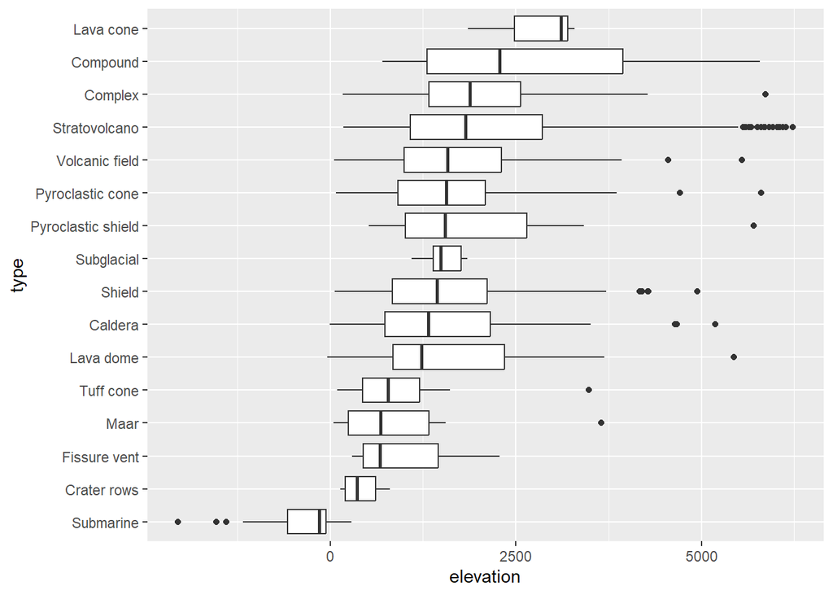

```r
volcano = volcano %>% mutate(type = str_remove(primary_volcano_type,"\\(s\\)|\\(es\\)|\\?"))

volcano %>% mutate(type = reorder(type, elevation, median)) %>%
  ggplot(aes(x = type, y = elevation)) +
  geom_boxplot() +
  coord_flip()
```

Next, let us examine the number of volcanoes across continents. The file continents_practice.csv classifies countries into continents. We’ve read it in as region. Fill in the blanks in the code to create the bar chart below.

2 ways to do this. 1. use geom_bar(), aes is Continent, geom_text with `label = ..count.., stat = “count”

2. summarize the data with group_by, geom_col(x = continents, y = count, label = count) then geom_text()

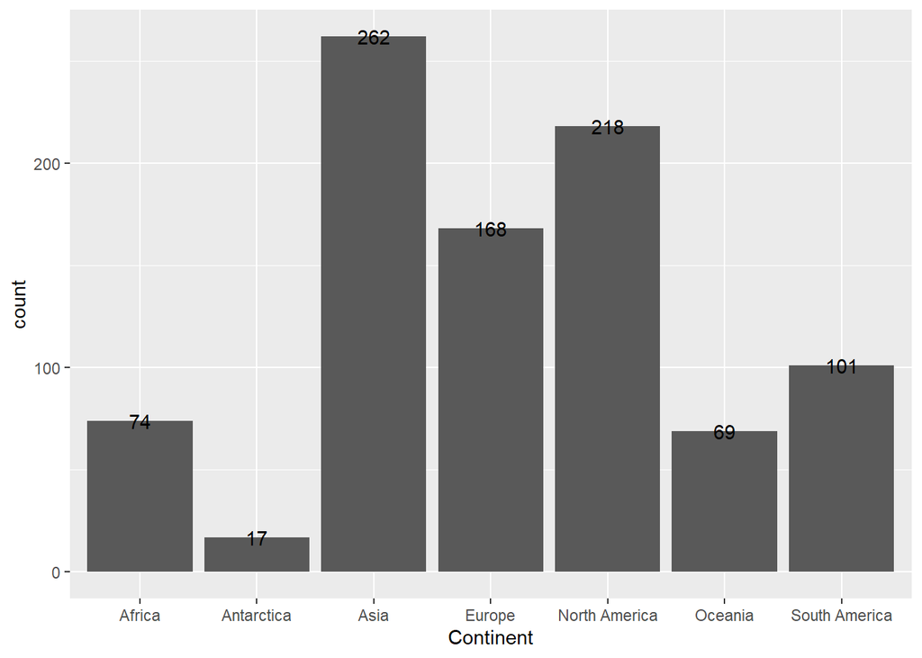

```r
continents= read.csv("../data/continents_practice.csv")

volcano =volcano %>% left_join(continents, by = c("country" = "Entity"))



ggplot(data = volcano, aes(Continent)) +
  geom_bar() +
  geom_text(aes(label = ..count..), stat = "count")
```

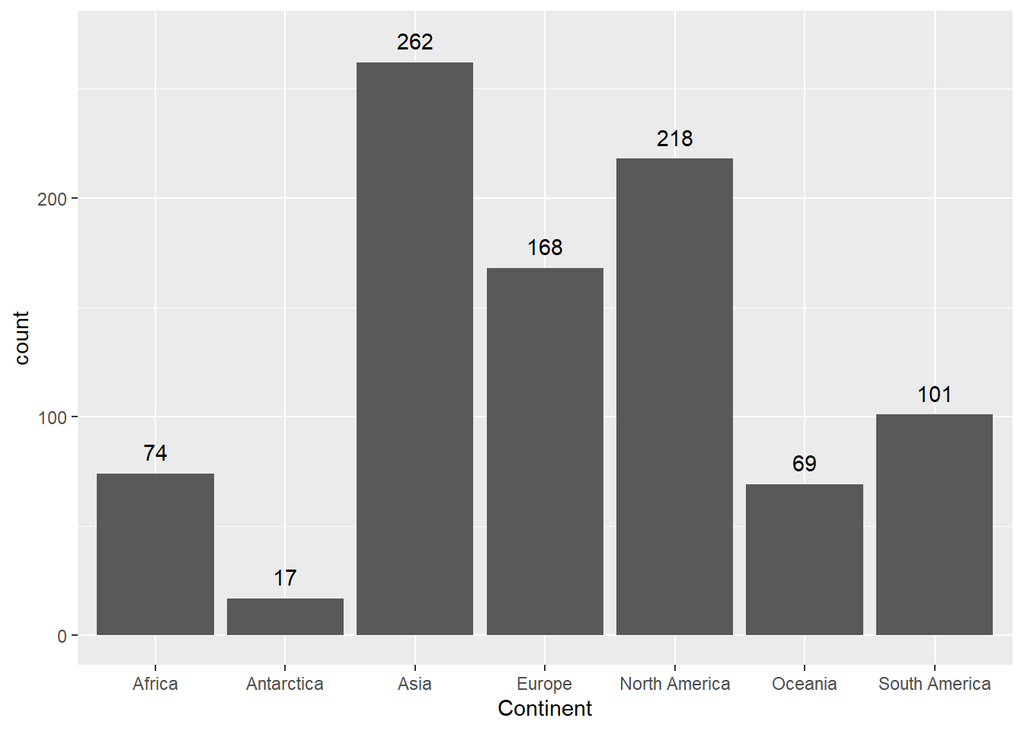

```r
v1 =volcano %>% group_by(Continent) %>%
  summarize(count = n())

ggplot(data = v1, aes(Continent, count, label = count)) +
  geom_col() +
  geom_text(nudge_y = 10.0)
```

```r
v1 %>% mutate(pct = count/sum(count) * 100)
```

```
## # A tibble: 7 × 3
##   Continent     count   pct
##   <chr>         <int> <dbl>
## 1 Africa           74  8.14
## 2 Antarctica       17  1.87
## 3 Asia            262 28.8
## 4 Europe          168 18.5
## 5 North America   218 24.0
## 6 Oceania          69  7.59
## 7 South America   101 11.1
```

The company wants to figure out when people begin Christmas shopping, so that they can start preparing for it. ▶ Write the R code to create an object named qn1 that contain the number of Christmas-related items sold in each month. Specifically, look for the following keywords in the Description column: CHRISTMASS, XMAS, REINDEER, or SANTA

```r
retail = readRDS("../data/retail_practice.rds")%>%
  mutate(InvoiceDate = as.Date(InvoiceDate),
         month = month(InvoiceDate, label = TRUE, abbr =TRUE),
         year = year(InvoiceDate),
         day = day(InvoiceDate))


qn1 = retail %>% filter(str_detect(Description, "CHRISTMAS|XMAS|REINDEER|SANTA")) %>%
  group_by(year, month) %>% summarize(n = n(), .groups = "drop")

qn1.1 = retail %>% filter(str_detect(Description, "CHRISTMAS|XMAS|REINDEER|SANTA")) %>%
  count(year, month)

qn1 %>% head(4)
```

```
## # A tibble: 4 × 3
##    year month     n
##   <dbl> <ord> <int>
## 1  2010 Dec      80
## 2  2011 Jan       3
## 3  2011 Feb       2
## 4  2011 Mar       1
```

```r
qn1.1 %>% head(4)
```

```
## # A tibble: 4 × 3
##    year month     n
##   <dbl> <ord> <int>
## 1  2010 Dec      80
## 2  2011 Jan       3
## 3  2011 Feb       2
## 4  2011 Mar       1
```

```r
retail %>% group_by(year, month) %>% distinct(day) %>% count()
```

```
## # A tibble: 13 × 3
## # Groups:   year, month [13]
##     year month     n
##    <dbl> <ord> <int>
##  1  2010 Dec      20
##  2  2011 Jan      24
##  3  2011 Feb      24
##  4  2011 Mar      27
##  5  2011 Apr      21
##  6  2011 May      25
##  7  2011 Jun      26
##  8  2011 Jul      26
##  9  2011 Aug      26
## 10  2011 Sep      26
## 11  2011 Oct      26
## 12  2011 Nov      26
## 13  2011 Dec       8
```

```r
qn2 = retail %>%
  mutate(InvoiceDate = as_date(InvoiceDate),
         month = substr(InvoiceDate, 1, 7)) %>%
  # Compute number of unique days in each month and monthly revenue
  group_by(month) %>%
  summarize(days = n_distinct(InvoiceDate),
            rev = sum(UnitPrice*Quantity)/1000) %>%
  ungroup()

qn2 %>% filter(month != "2011-12") %>% summarize(mean_days = mean(days))
```

```
## # A tibble: 1 × 1
##   mean_days
##       <dbl>
## 1      24.8
```

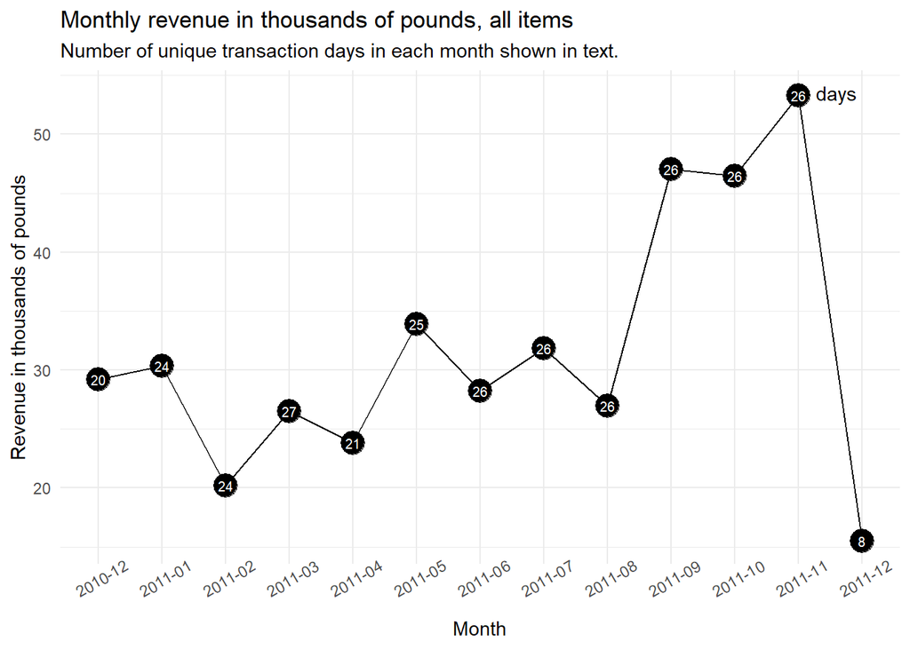

```r
ggplot(data = qn2, aes(x = factor(month), y = rev)) +
  geom_point(size = 6) +
  geom_line(aes(group = 1)) +
  geom_text(aes(label = days), color = "white", size = 2.7) +
  annotate(geom = "text", x = 12.6, y = 53.5, label = "days") +
  labs(title = "Monthly revenue in thousands of pounds, all items",
       x = "Month", y = "Revenue in thousands of pounds",
       subtitle = "Number of unique transaction days in each month shown in text.") +
  theme_minimal() +
  theme(axis.text.x = element_text(angle = 30))
```

Notice that 2011 Dec only have 8 days, we can try to increase the number of days and quantify by scaling the number of days to average days per month in the dataset.

```r
library(nycflights13)
library(tidyverse)
library(readxl)
library(stringr)
library(lubridate)

flights %>% filter(month == 12, origin == "JFK") %>% group_by(dest) %>% count(sort = TRUE)
```

```
## # A tibble: 64 × 2
## # Groups:   dest [64]
##    dest      n
##    <chr> <int>
##  1 LAX     947
##  2 SFO     698
##  3 BOS     495
##  4 MCO     451
##  5 SJU     450
##  6 FLL     385
##  7 LAS     309
##  8 MIA     289
##  9 BUF     286
## 10 TPA     282
## # ℹ 54 more rows
```

```r
flights %>% group_by(carrier) %>%
  summarize(count = n(), avg_dist = sum(distance)/count) %>%
  arrange(desc(avg_dist))
```

```
## # A tibble: 16 × 3
##    carrier count avg_dist
##    <chr>   <int>    <dbl>
##  1 HA        342    4983
##  2 VX       5162    2499.
##  3 AS        714    2402
##  4 F9        685    1620
##  5 UA      58665    1529.
##  6 AA      32729    1340.
##  7 DL      48110    1237.
##  8 B6      54635    1069.
##  9 WN      12275     996.
## 10 FL       3260     665.
## 11 MQ      26397     570.
## 12 EV      54173     563.
## 13 US      20536     553.
## 14 9E      18460     530.
## 15 OO         32     501.
## 16 YV        601     375.
```

```r
flights %>% filter(arr_delay > 0, !is.na(arr_delay)) %>%
  group_by(month, day) %>%
  summarize(avg_delay = sum(arr_delay) / n()) %>%
  arrange(desc(avg_delay))
```

```
## # A tibble: 365 × 3
## # Groups:   month [12]
##    month   day avg_delay
##    <int> <int>     <dbl>
##  1     7    10     110.
##  2     9     2     103.
##  3     7    22     102.
##  4     9    12     100.
##  5     3     8      97.5
##  6     4    10      94.1
##  7     6    24      92.1
##  8     5    23      88.5
##  9     6    27      88.4
## 10     7    28      86.6
## # ℹ 355 more rows
```

```r
flights %>% filter(month == 7, day == 4) %>%
  left_join(planes, by = c("tailnum")) %>%
  filter(!is.na(dep_time)) %>%
  summarize(avg_seats = round(mean(seats, na.rm = TRUE), 2)) %>% pull(avg_seats)
```

```
## [1] 140.56
```

```r
flights %>% mutate(dep_hour = as.integer(sched_dep_time / 100)) %>%
  group_by(dep_hour) %>%
  mutate(over = case_when(dep_delay > 15 ~ 1,
                          TRUE ~ 0)) %>%
  summarize(p = sum(over) / n()) %>%
  arrange(desc(p))
```

```
## # A tibble: 20 × 2
##    dep_hour      p
##       <int>  <dbl>
##  1       21 0.358
##  2       20 0.345
##  3       19 0.334
##  4       22 0.309
##  5       18 0.301
##  6       17 0.296
##  7       16 0.275
##  8       15 0.266
##  9       23 0.257
## 10       14 0.227
## 11       13 0.211
## 12       12 0.177
## 13       11 0.154
## 14       10 0.136
## 15        9 0.118
## 16        8 0.110
## 17        7 0.0810
## 18        6 0.0738
## 19        5 0.0594
## 20        1 0
```

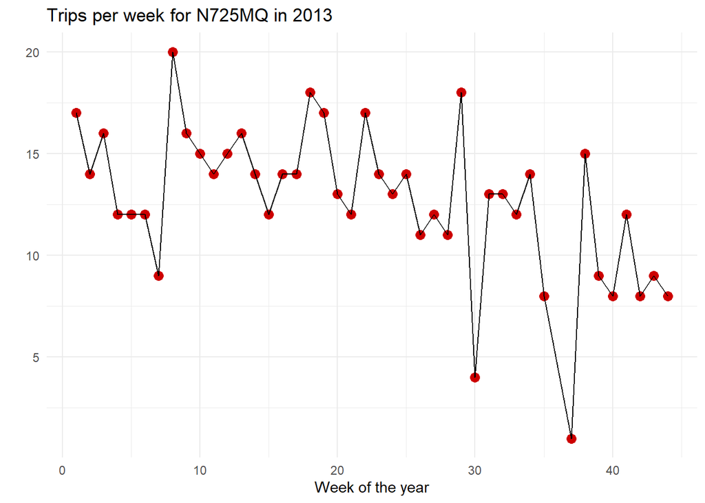

```r
# What plane traveled the most times in 2013? Plot the number of trips per week over the year for that plane.
plane = flights  %>% left_join(planes, by = c("tailnum" = "tailnum")) %>%
  filter(year.x == 2013, !(is.na(dep_time))) %>%
  group_by(tailnum) %>%
  summarize(count = n()) %>%
  arrange(desc(count)) %>%
  top_n(1, count) %>% pull(tailnum)

most = flights %>% filter(tailnum == plane, !(is.na(dep_time)))
most_trip = flights %>% filter(tailnum == plane, !(is.na(dep_time))) %>%
  unite(col = date,year,  month, day, sep = "-") %>%
  mutate(date = as.Date(date),
         week = week(date)) %>%
  group_by(week) %>%
  summarize(count = n())

ggplot(data = most_trip, aes(week, count)) +
  geom_point(color = "red3", size = 3) +
  geom_line() +
  labs(x = "Week of the year", y = "", title = "Trips per week for N725MQ in 2013") +
  theme_minimal()
```

```r
colnms <- colnames(most)

# filter
most %>%
  filter_at(vars(all_of(colnms)), any_vars(is.na(.)))
```

```
## # A tibble: 2 × 19
##    year month   day dep_time sched_dep_time dep_delay arr_time sched_arr_time
##   <int> <int> <int>    <int>          <int>     <dbl>    <int>          <int>
## 1  2013     5    20     1837           1800        37     2252           2025
## 2  2013     6     5      742            700        42     1116            920
## # ℹ 11 more variables: arr_delay <dbl>, carrier <chr>, flight <int>,
## #   tailnum <chr>, origin <chr>, dest <chr>, air_time <dbl>, distance <dbl>,
## #   hour <dbl>, minute <dbl>, time_hour <dttm>
```

scatterplot

```r
data(mpg)
str(mpg)
```

```
## tibble [234 × 11] (S3: tbl_df/tbl/data.frame)
##  $ manufacturer: chr [1:234] "audi" "audi" "audi" "audi" ...
##  $ model       : chr [1:234] "a4" "a4" "a4" "a4" ...
##  $ displ       : num [1:234] 1.8 1.8 2 2 2.8 2.8 3.1 1.8 1.8 2 ...
##  $ year        : int [1:234] 1999 1999 2008 2008 1999 1999 2008 1999 1999 2008 ...
##  $ cyl         : int [1:234] 4 4 4 4 6 6 6 4 4 4 ...
##  $ trans       : chr [1:234] "auto(l5)" "manual(m5)" "manual(m6)" "auto(av)" ...
##  $ drv         : chr [1:234] "f" "f" "f" "f" ...
##  $ cty         : int [1:234] 18 21 20 21 16 18 18 18 16 20 ...
##  $ hwy         : int [1:234] 29 29 31 30 26 26 27 26 25 28 ...
##  $ fl          : chr [1:234] "p" "p" "p" "p" ...
##  $ class       : chr [1:234] "compact" "compact" "compact" "compact" ...
```

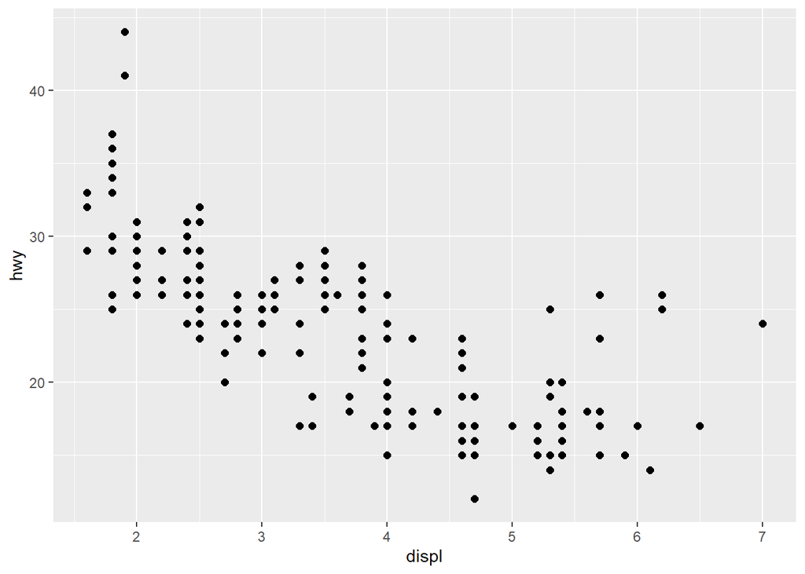

```r
df = mpg %>% mutate(trans = str_sub(trans, 1, 4))

df1 = mpg %>% mutate(trans = case_when(str_detect(trans, "^auto") ~ "auto",
                                       str_detect(trans, "^manual") ~ "manual",
                                       TRUE ~ trans))

ggplot(data = df1, aes(x = displ, y = hwy, label = trans)) +
  geom_point(size = 2,  alpha = 1)
```

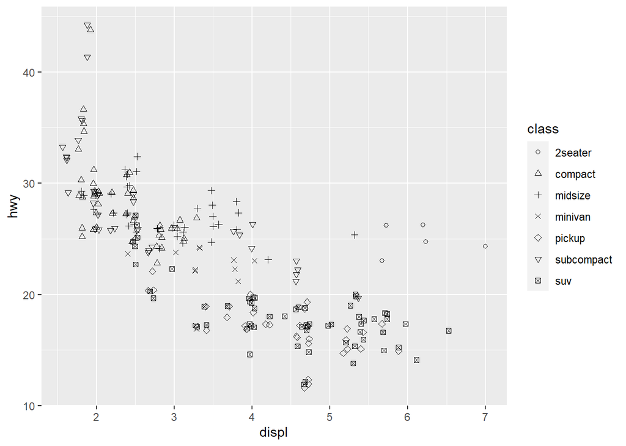

```r
ggplot(data = df1, aes(x = displ, y = hwy, label = trans)) +
  geom_point(aes(shape = class),position = "jitter")  +
  scale_shape_manual(values = 1:7)
```

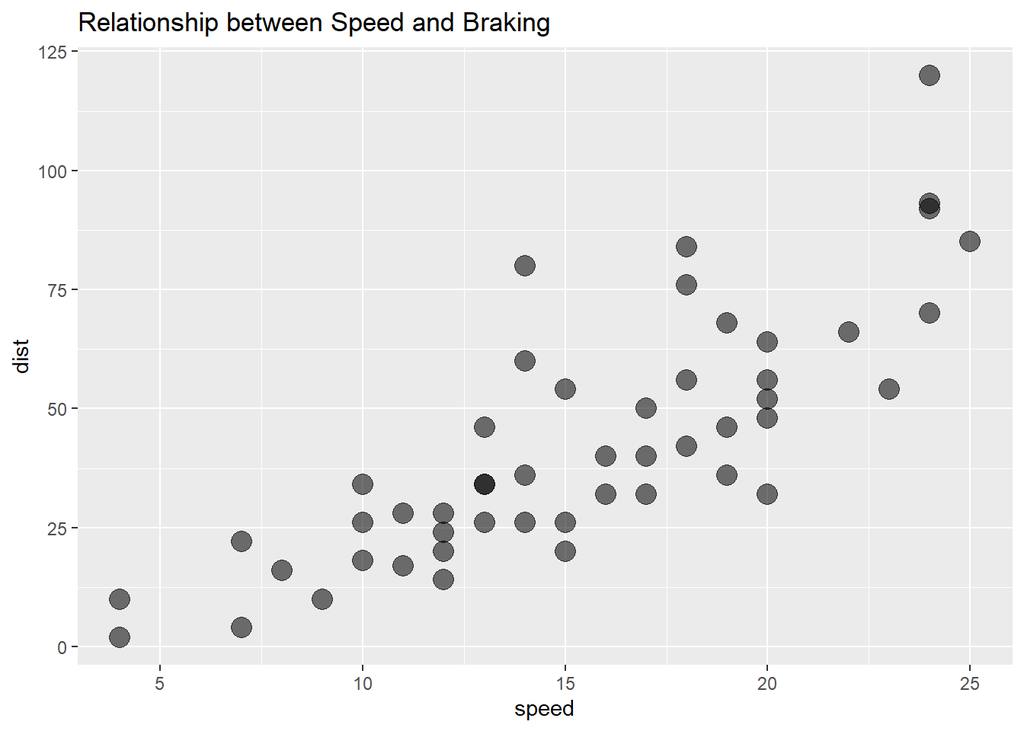

```r
ggplot(data = cars, aes(speed, dist)) +
  geom_point(aes(size = 2.0,alpha = 0.4), show.legend = FALSE) +
  labs(title = "Relationship between Speed and Braking",
       ylab = "Stopping distance (ft)",
       xlab = "Speed (mph)")
```

Histogram

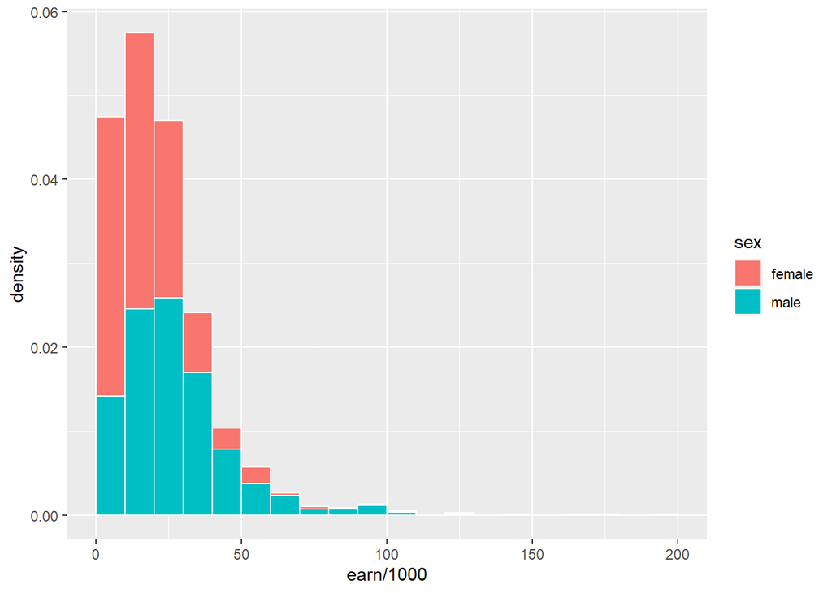

```r
heights = read.csv("../data/heights.csv", header= TRUE, stringsAsFactors = TRUE)

ggplot(data = heights) +
  geom_histogram(aes(x = earn/1000, y = ..density.., fill = sex),
                 binwidth = 10, color = "white", boundary = 0)
```

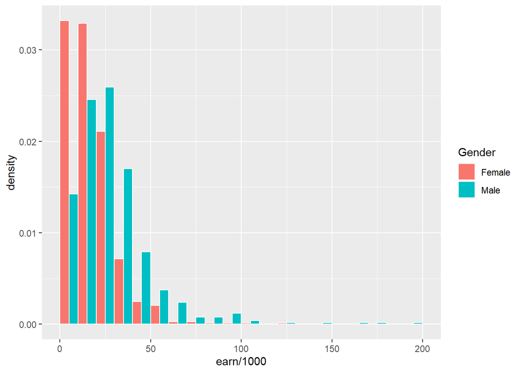

```r
ggplot(data = heights) +
  geom_histogram(aes(x = earn/1000, y = ..density.., fill = sex),
                 binwidth = 10, color = "white", boundary = 0, position = "dodge") +
  scale_fill_discrete(name = "Gender", labels = c("Female", "Male"))
```

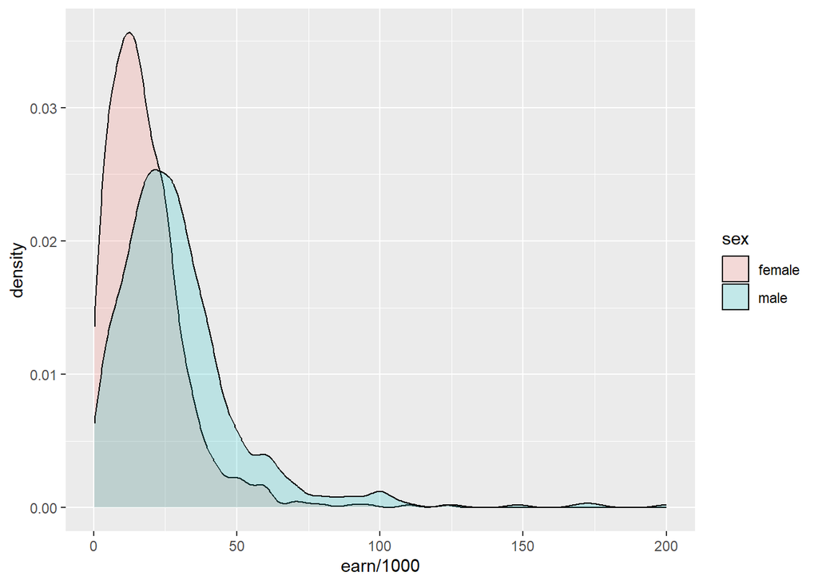

```r
ggplot(data = heights) +
  geom_density(aes(x= earn/1000, fill = sex), alpha = 0.2)
```

CDF

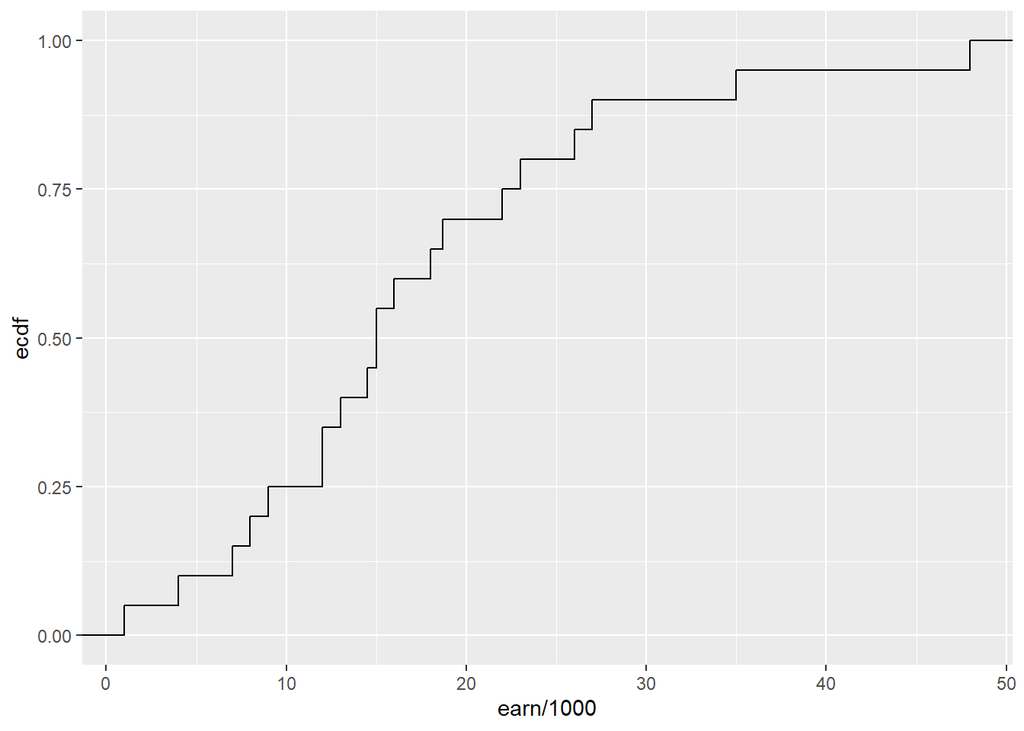

```r
heights %>%
  filter(sex == "female") %>%
  sample_n(20) %>%
  ggplot(aes(x = earn/1000)) +
  stat_ecdf()
```

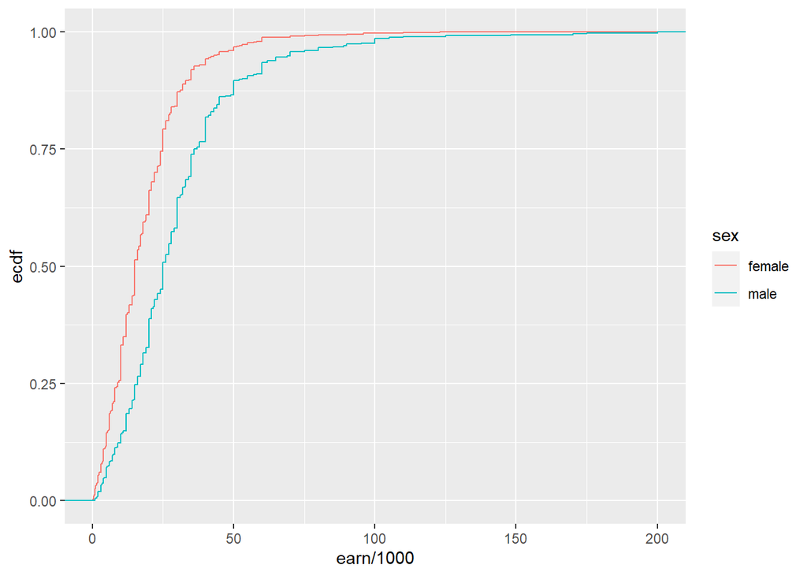

```r
heights %>%
  ggplot(aes(x = earn/1000, col = sex)) +
  stat_ecdf()
```

normal dist

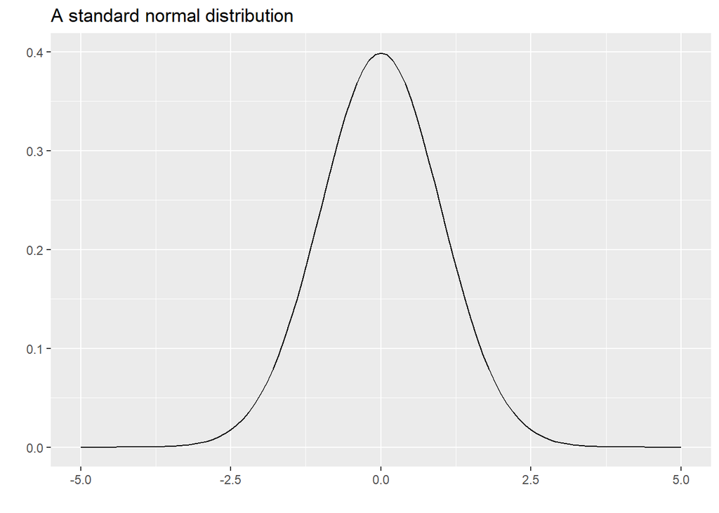

```r
ggplot(data = data.frame(x = seq(-5, 5)), aes(x)) +
stat_function(fun = dnorm, n = 101, args = list(mean = 0, sd = 1)) +
labs(x = "", y = "", title = "A standard normal distribution")
```

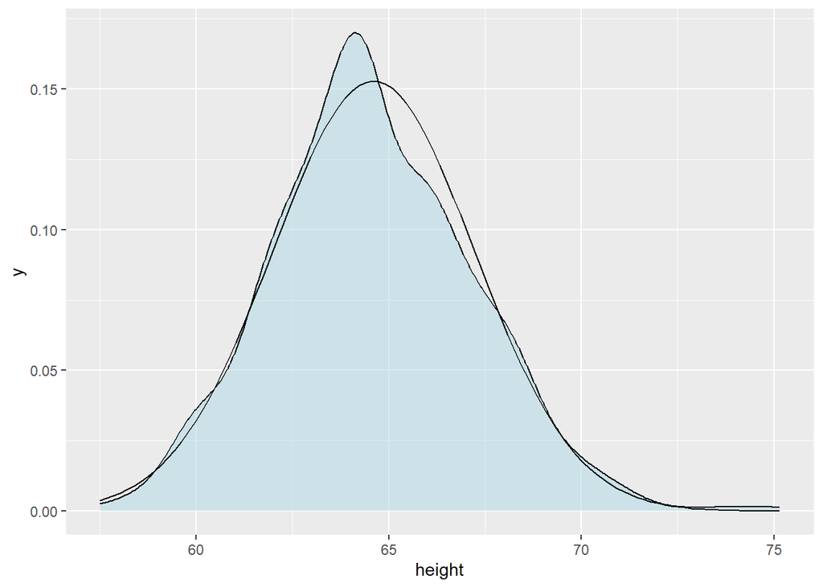

```r
heights_f = heights %>% filter(sex == "female")

heights_f %>%
  ggplot(aes(height)) +
  geom_density(fill = "lightblue", alpha = 0.5) +
  stat_function(fun = dnorm, args = list(mean(heights_f$height), sd(heights_f$height)))
```

line graphs

```r
UN_data = read_excel("../data/UNESCAP_population_2010_2015.xlsx", sheet = 3)
head(UN_data)
```

```
## # A tibble: 6 × 7
##   e_fname     Y2010 Y2011 Y2012 Y2013 Y2014 Y2015
##   <chr>       <dbl> <dbl> <dbl> <dbl> <dbl> <dbl>
## 1 Afghanistan  2447  2459  2454  2438  2422  2412
## 2 Armenia        92    94    97    99   101   101
## 3 Australia     710   731   740   743   745   752
## 4 Azerbaijan    333   348   370   394   413   425
## 5 Bangladesh   7725  7622  7565  7540  7525  7503
## 6 Bhutan         35    35    35    34    33    32
```

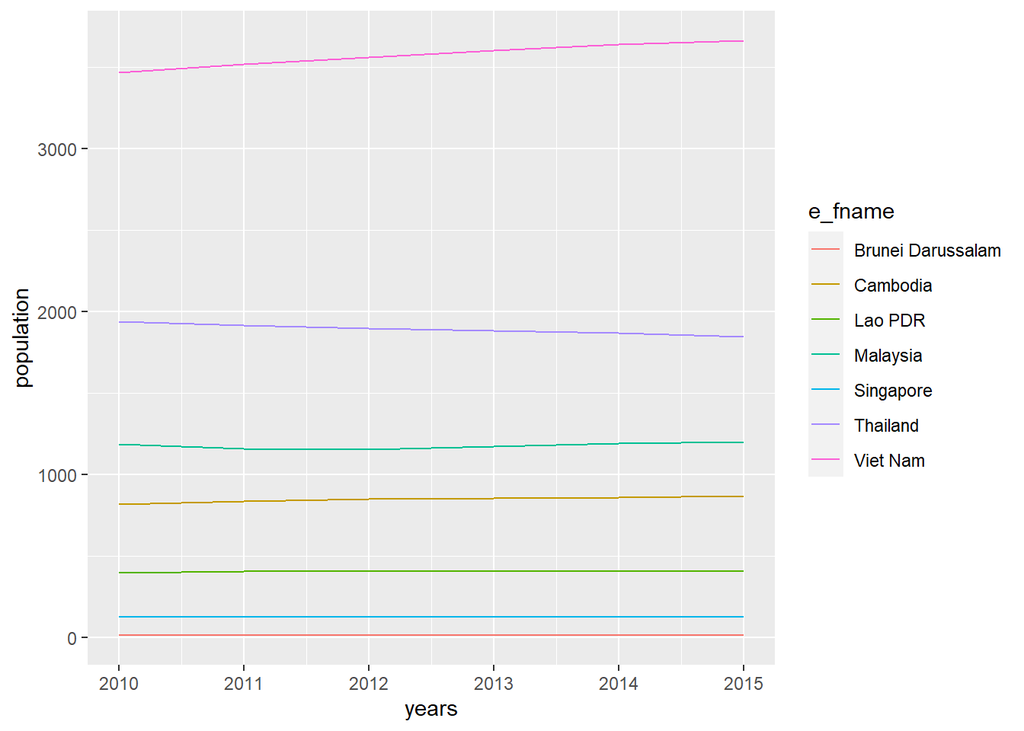

```r
pop1 = UN_data %>% gather(Y2010:Y2015, key = years, value = population) %>%
  mutate(years = as.integer(str_sub(years, 2, 5))) %>%
  filter(e_fname %in% c("Singapore", "Malaysia", "Cambodia",
  "Thailand", "Viet Nam", "Lao PDR",
  "Brunei Darussalam"))

ggplot(data = pop1, aes(years, population)) +
  geom_line(aes(color = e_fname))
```

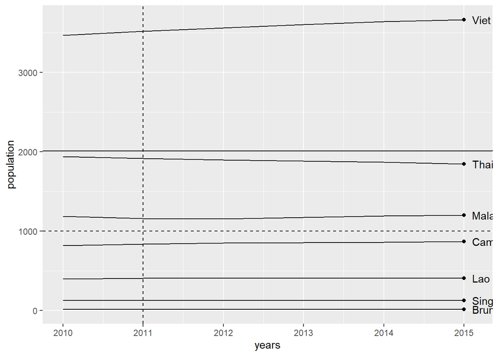

```r
end_pts = pop1 %>% filter(years == 2015) %>%
  mutate(fname = recode(e_fname, "Brunei Darussalam" = "Brunei"))

ggplot(data = pop1, aes(years, population, group = e_fname)) +
  geom_line() +
  geom_point(data = end_pts, aes(years)) +
  geom_text(data = end_pts, aes(label = fname), hjust = "left", nudge_x = 0.1) +
  geom_vline(xintercept = 2011, linetype = "dashed") +
  geom_hline(yintercept = 1000, linetype = "dashed") +
  geom_abline(slope = 1)
```

reconstruction of graph

```r
library(dslabs)
library(ggthemes)

df = murders
head(df)
```

```
##        state abb region population total
## 1    Alabama  AL  South    4779736   135
## 2     Alaska  AK   West     710231    19
## 3    Arizona  AZ   West    6392017   232
## 4   Arkansas  AR  South    2915918    93
## 5 California  CA   West   37253956  1257
## 6   Colorado  CO   West    5029196    65
```

```r
df %>% distinct(state)
```

```
##                   state
## 1               Alabama
## 2                Alaska
## 3               Arizona
## 4              Arkansas
## 5            California
## 6              Colorado
## 7           Connecticut
## 8              Delaware
## 9  District of Columbia
## 10              Florida
## 11              Georgia
## 12               Hawaii
## 13                Idaho
## 14             Illinois
```

[output cut: 37 more lines]

```r
df %>% count(state)
```

```
##                   state n
## 1               Alabama 1
## 2                Alaska 1
## 3               Arizona 1
## 4              Arkansas 1
## 5            California 1
## 6              Colorado 1
## 7           Connecticut 1
## 8              Delaware 1
## 9  District of Columbia 1
## 10              Florida 1
## 11              Georgia 1
## 12               Hawaii 1
## 13                Idaho 1
## 14             Illinois 1
```

[output cut: 37 more lines]

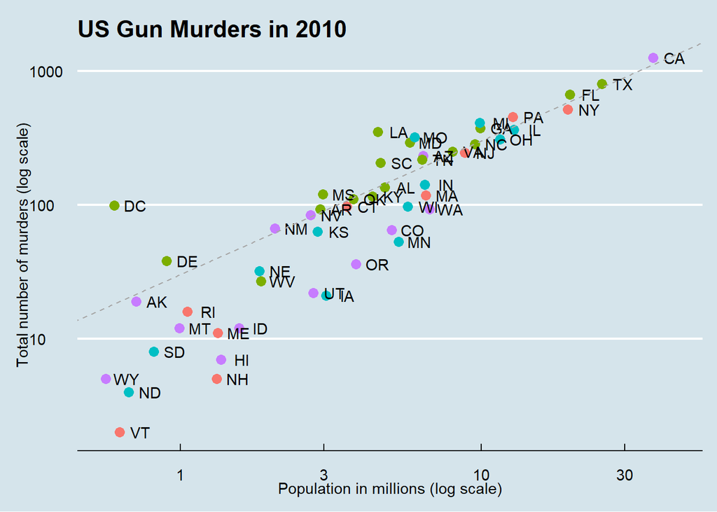

```r
r = df %>% summarize(rate = sum(total)/ (sum(population) / 1e6)) %>%
  pull(rate)

df %>% ggplot(aes(x = population/1e6, y = total)) +
  geom_point(aes(color = region), size = 3,  show.legend = FALSE) +
  geom_text(aes(label = abb), nudge_x = 0.07) +
  scale_x_log10() +
  scale_y_log10() +
  labs(title = "US Gun Murders in 2010",
    x = "Population in millions (log scale)",
    y = "Total number of murders (log scale)") +
  geom_abline(slope = 1, intercept = log10(r), lty = 2, color = "darkgrey") +
  theme_economist()
```

bar charts

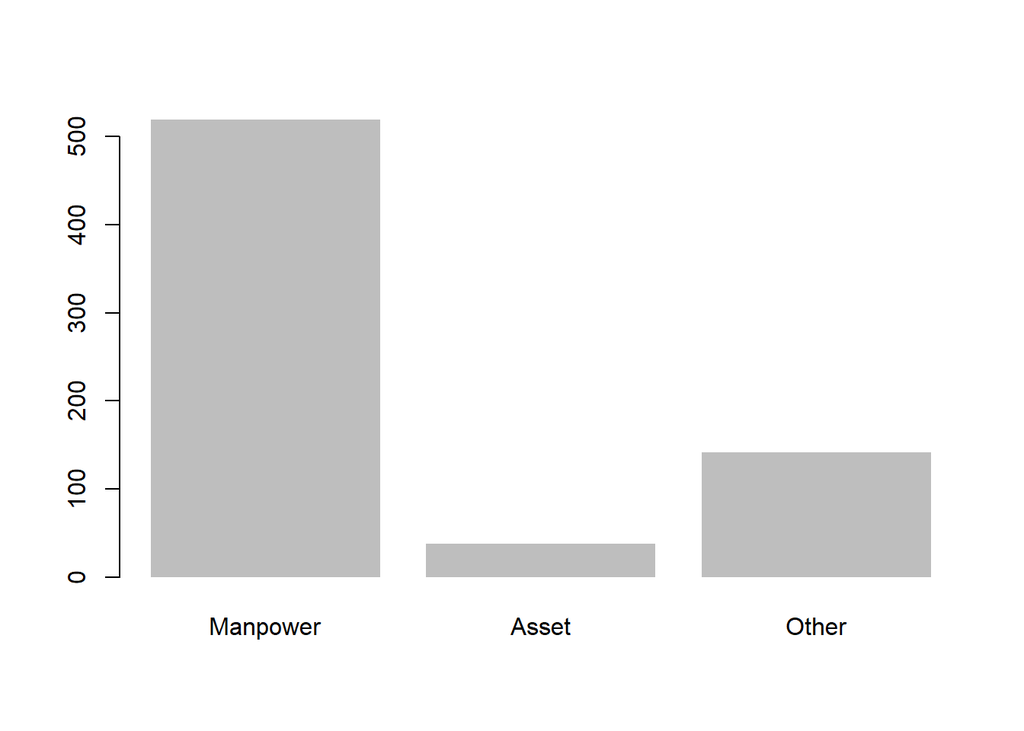

```r
budget_cat = c("Manpower", "Asset", "Other") # create data frame
amount = c(519.4, 38.0, 141.4)
op_budget = data.frame(budget_cat, amount)
barplot(op_budget$amount, border = NA, names.arg = op_budget$budget_cat)
```

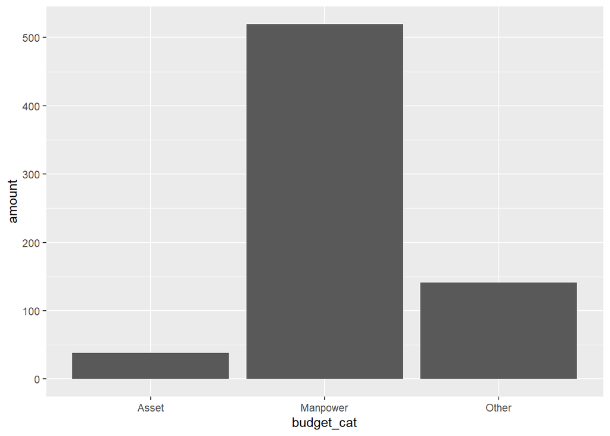

```r
ggplot(data = op_budget, aes(budget_cat, amount)) +
  geom_col()
```

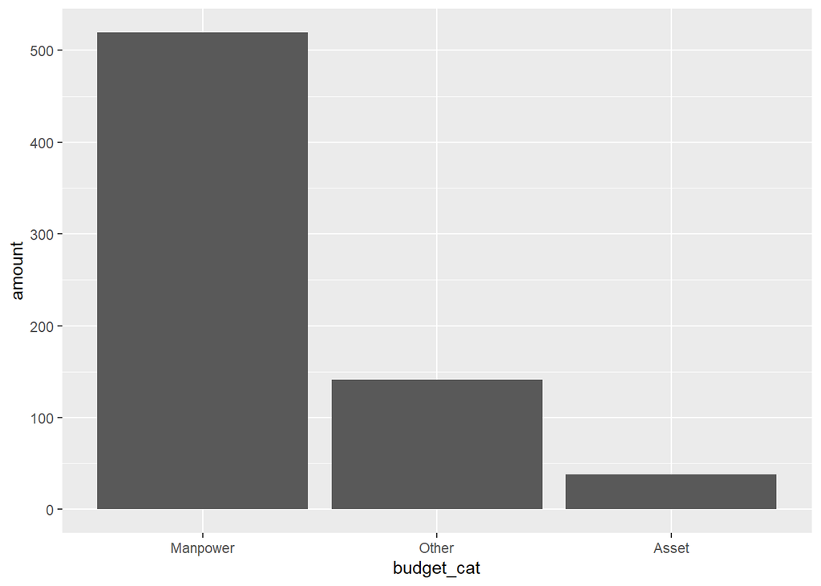

```r
op_budget %>% mutate(budget_cat = reorder(budget_cat, -amount)) %>%
  ggplot(aes(budget_cat, amount)) +
  geom_col()
```

```r
imda_data = readRDS("../data/imda.rds")
str(imda_data)
```

```
## 'data.frame':    210 obs. of  6 variables:
##  $ ever_used     : chr  "97.1" "32.9" "39.5" "30.9" ...
##  $ age           : chr  "15-19" "15-19" "15-19" "15-19" ...
##  $ sample_size   : chr  "161" "161" "161" "161" ...
##  $ year          : chr  "2013" "2013" "2013" "2013" ...
##  $ _id           : int  1 2 3 4 5 6 7 8 9 10 ...
##  $ media_activity: chr  "Watch MediaCorp TV" "Watch Singtel TV" "Watch StarHub TV" "Watch animation" ...
```

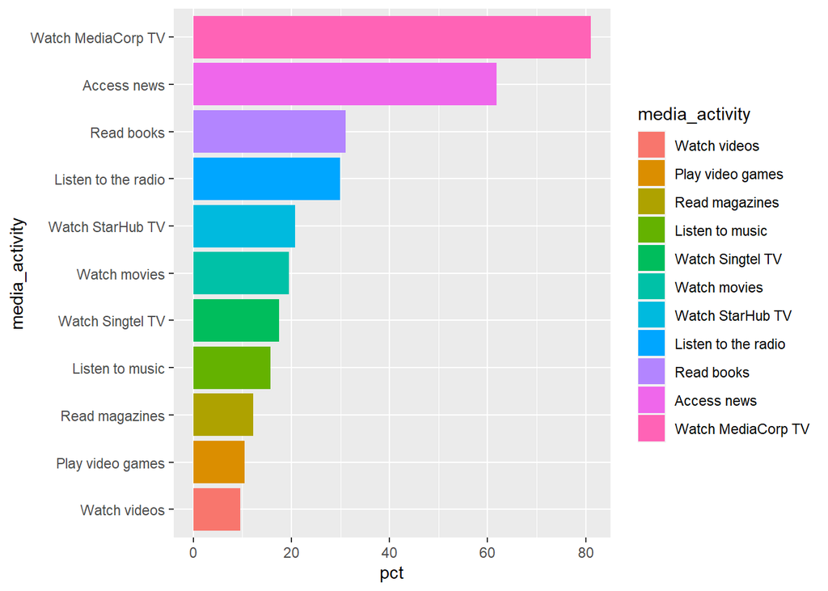

```r
young_adults = imda_data %>% filter(age == "20-29", year == 2015) %>%
  mutate(pct = as.numeric(ever_used),
         media_activity = reorder(media_activity, pct))

ggplot(data = young_adults) +
  geom_col(aes(media_activity, pct, fill = media_activity)) +
  coord_flip()
```

```r
tv = imda_data %>%
  filter(media_activity %in% c("Watch MediaCorp TV",
                               "Watch StarHub TV", "Watch Singtel TV")) %>%
  mutate(pct = as.numeric(ever_used),
         age = reorder(as.factor(age), as.numeric(substr(age, 1, 2))))


p1 = ggplot(tv, aes(x = year, y = pct)) +
  geom_col(aes(fill = media_activity),
           position = "dodge") +
  facet_wrap(~ age) +
  labs(title = "Percentage of Young Adults ...",
       x = "Activity", y = "Percentage", fill = "Activity") +
  theme(legend.position = "bottom")
```

smoothed line & loess

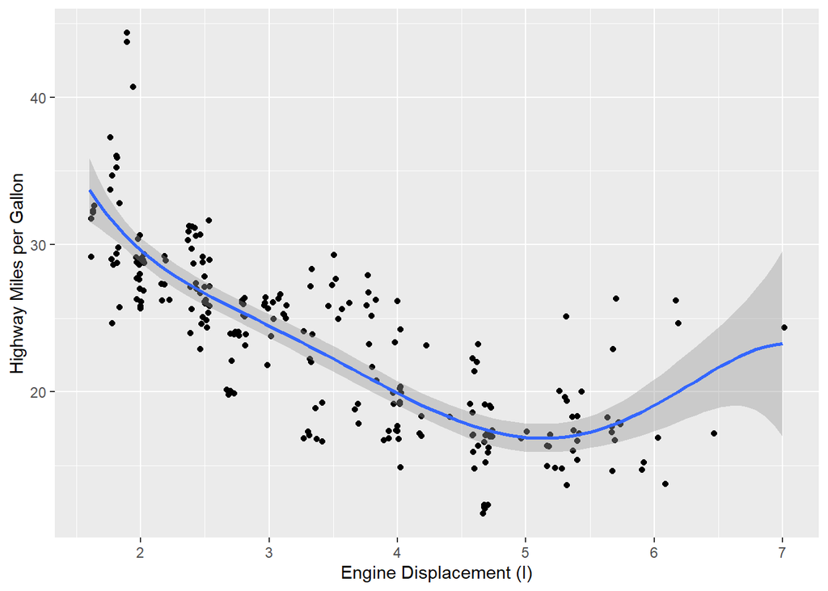

```r
ggplot(data = mpg, mapping = aes(x = displ, y = hwy)) +
  geom_point(position = "jitter") +
  geom_smooth(method = "lm", formula = y ~ poly(x, 5)) +
  labs(x = "Engine Displacement (l)", y = "Highway Miles per Gallon")
```

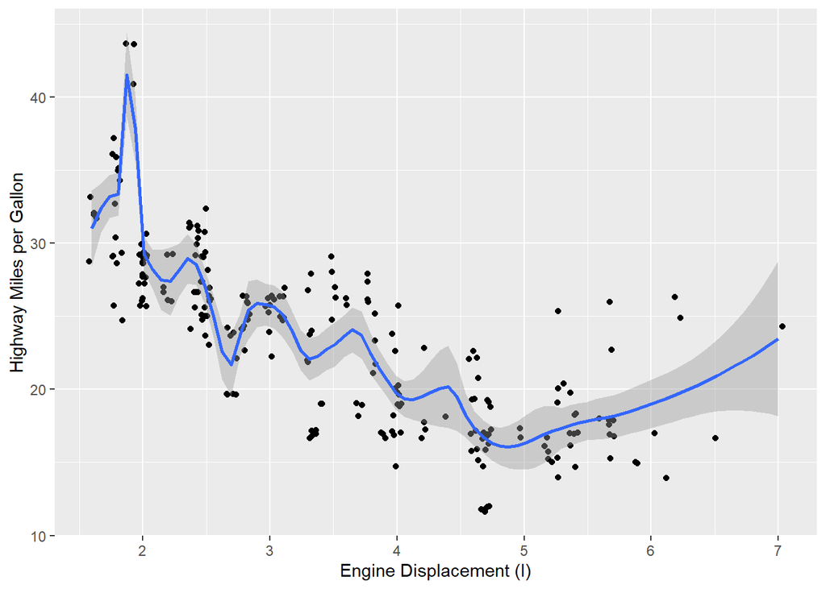

```r
ggplot(mpg, aes(x = displ, y = hwy)) +
  geom_point(position = "jitter") +
  geom_smooth(method = "loess", span = 0.2) +
  labs(x = "Engine Displacement (l)", y = "Highway Miles per Gallon")
```

loess by group

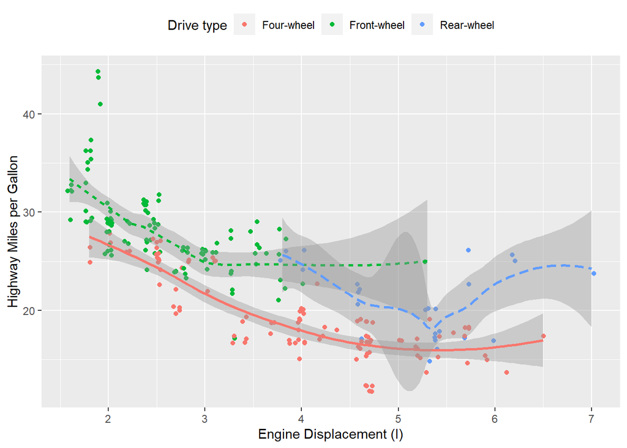

```r
ggplot(mpg, aes(x = displ, y = hwy, col = drv)) +
  geom_point(position = "jitter") +
  geom_smooth(aes(linetype = drv),
              method = "loess", show.legend = FALSE) +
  labs(x = "Engine Displacement (l)", y = "Highway Miles per Gallon") +
  scale_color_discrete(name = "Drive type",
  labels = c("Four-wheel", "Front-wheel", "Rear-wheel")) +
  theme(legend.position = "top")
```

rug plot

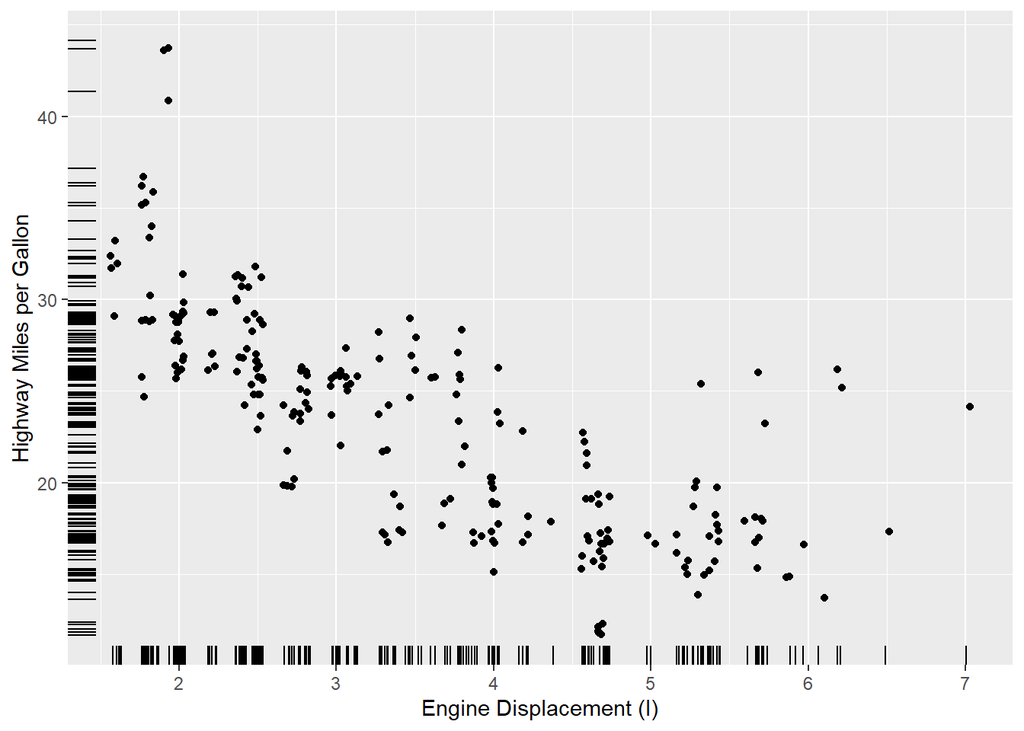

```r
ggplot(mpg, aes(x = displ, y = hwy)) +
  geom_point(position = "jitter") +
  geom_rug(position = "jitter") +
  labs(x = "Engine Displacement (l)", y = "Highway Miles per Gallon")
```

boxplot

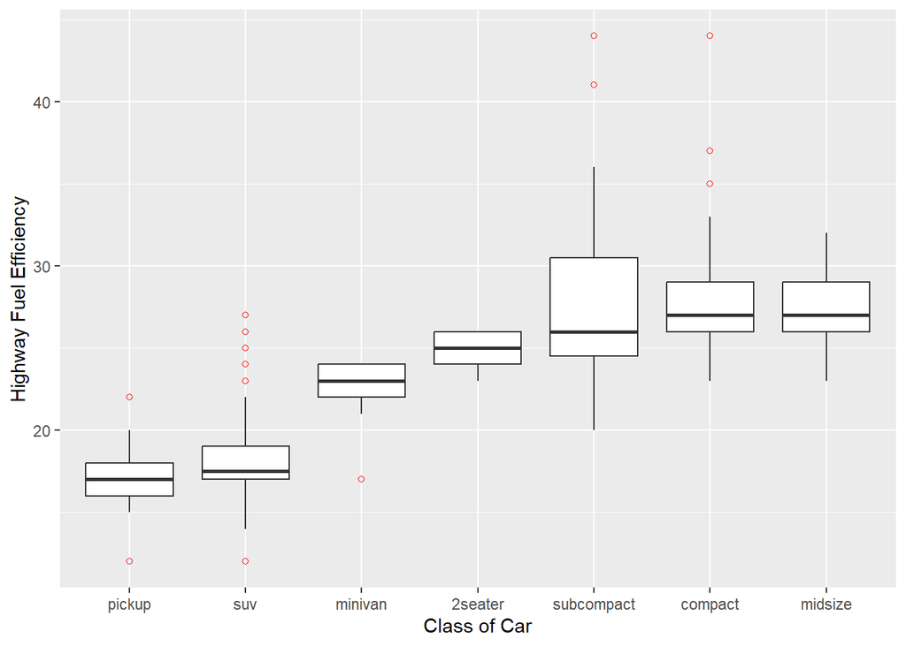

```r
df = mpg %>% mutate(class = reorder(class, hwy, FUN = median))

ggplot(df, aes(x = class, y = hwy)) +
  geom_boxplot(outlier.color = "red",  outlier.shape = 1) +
  labs(x = "Class of Car", y = "Highway Fuel Efficiency")
```

remove outliers

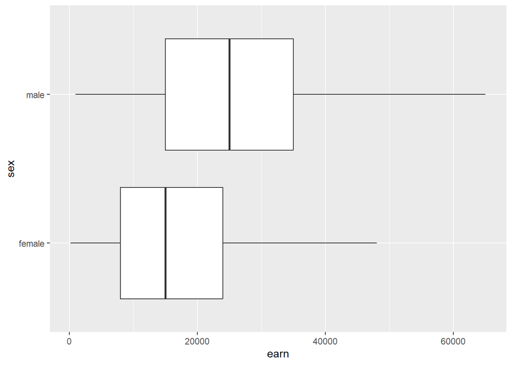

```r
heights2 = heights %>%
  group_by(sex) %>%
  mutate(max_earn = quantile(earn, 0.75) + 1.5 * IQR(earn),
  min_earn = quantile(earn, 0.25) - 1.5 * IQR(earn)) %>%
  filter(earn <= max_earn & earn >= min_earn) %>% ungroup()

ggplot(data = heights2) +
geom_boxplot(aes(x = earn, y = sex))
```

2D Histograms

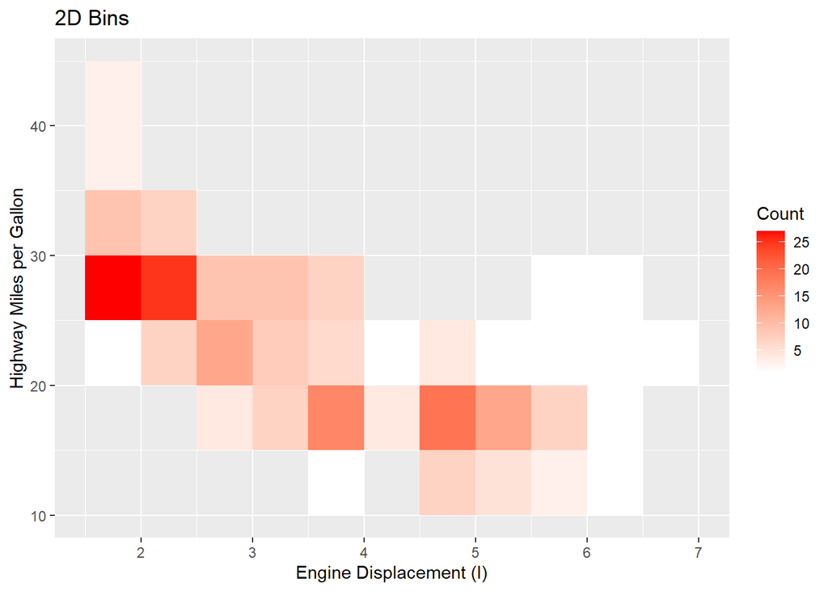

```r
ggplot(mpg, aes(x = displ, y = hwy)) +
  geom_bin2d(binwidth = c(0.5, 5)) +
  scale_fill_gradient(name = "Count", low = "white", high = "red") +
  labs(title = "2D Bins",
       x = "Engine Displacement (l)", y = "Highway Miles per Gallon")
```

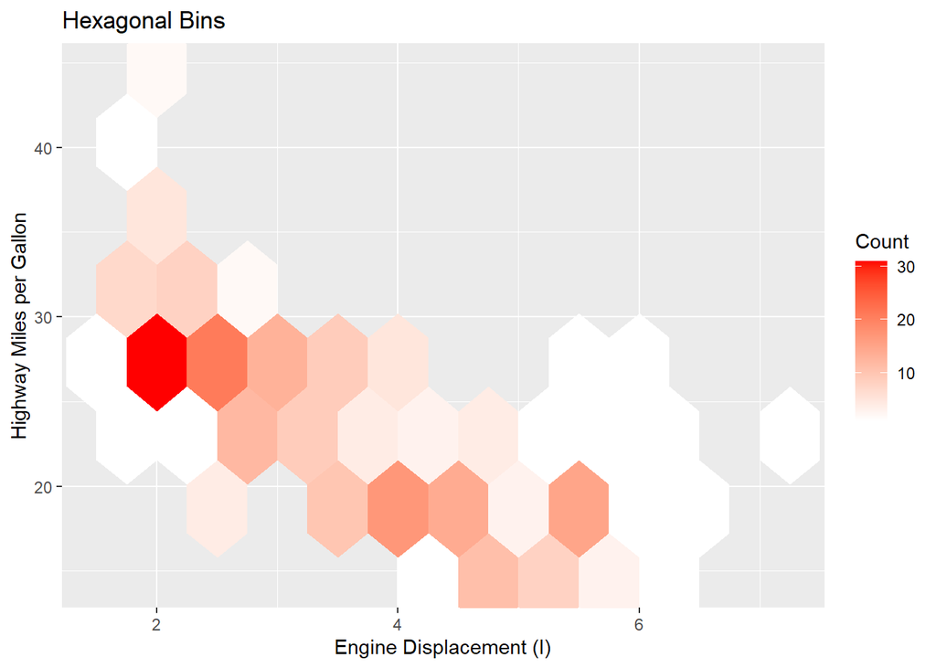

```r
ggplot(mpg, aes(x = displ, y = hwy)) +
  geom_hex(binwidth = c(0.5, 5)) +
  scale_fill_gradient(name = "Count", low = "white", high = "red") +
  labs(title = "Hexagonal Bins",
       x = "Engine Displacement (l)", y = "Highway Miles per Gallon")
```

```r
library(ggrepel)
data(gapminder)

summary(gapminder)
```

```
##                 country           year      infant_mortality life_expectancy
##  Albania            :   57   Min.   :1960   Min.   :  1.50   Min.   :13.20
##  Algeria            :   57   1st Qu.:1974   1st Qu.: 16.00   1st Qu.:57.50
##  Angola             :   57   Median :1988   Median : 41.50   Median :67.54
##  Antigua and Barbuda:   57   Mean   :1988   Mean   : 55.31   Mean   :64.81
##  Argentina          :   57   3rd Qu.:2002   3rd Qu.: 85.10   3rd Qu.:73.00
##  Armenia            :   57   Max.   :2016   Max.   :276.90   Max.   :83.90
##  (Other)            :10203                  NA's   :1453
##    fertility       population             gdp               continent
##  Min.   :0.840   Min.   :3.124e+04   Min.   :4.040e+07   Africa  :2907
##  1st Qu.:2.200   1st Qu.:1.333e+06   1st Qu.:1.846e+09   Americas:2052
##  Median :3.750   Median :5.009e+06   Median :7.794e+09   Asia    :2679
##  Mean   :4.084   Mean   :2.701e+07   Mean   :1.480e+11   Europe  :2223
##  3rd Qu.:6.000   3rd Qu.:1.523e+07   3rd Qu.:5.540e+10   Oceania : 684
##  Max.   :9.220   Max.   :1.376e+09   Max.   :1.174e+13
##  NA's   :187     NA's   :185         NA's   :2972
##              region
##  Western Asia   :1026
##  Eastern Africa : 912
##  Western Africa : 912
##  Caribbean      : 741
##  South America  : 684
##  Southern Europe: 684
##  (Other)        :5586
```

```r
gapminder %>% filter(!is.na(gdp)) %>%
  group_by(year) %>%
  count()
```

```
## # A tibble: 52 × 2
## # Groups:   year [52]
##     year     n
##    <int> <int>
##  1  1960    95
##  2  1961    96
##  3  1962    96
##  4  1963    96
##  5  1964    96
##  6  1965   102
##  7  1966   104
##  8  1967   105
##  9  1968   106
## 10  1969   106
## # ℹ 42 more rows
```